# Analysis of Treatment Policy Estimands

Practical Worksheet

24 September 2024

| **Tobias Mütze<sup>1</sup>** tobias.muetze@novartis.com | **Simon Newsome<sup>1</sup>** simon.newsome@novartis.com |
| --- | --- |
| <sup>1</sup>Novartis Pharma AG, Basel, Switzerland |  |

# Preface

This worksheet will guide you through an analysis of the example randomized controlled trial in patients with type 2 diabetes. The analyses in this worksheet target a **treatment policy estimand**, i.e., we are interested in the comparison between treatment versus placebo group **irrespective of whether or not patients experienced the intercurrent event** of treatment discontinuation.

This code is based on the *rbmi* vignette (https://cran.r-project.org/web/packages/rbmi/vignettes/quickstart.html), and was developed and tested using R v4.3.1 and rbmi v1.2.6.

# 1 Set up

First, ensure that the following packages are installed and loaded, and also set the working directory to the folder containing the example datasets.

```r
rm(list = ls())

###Install and load required packages
if(!require(tidyverse)) {install.packages("tidyverse"); library(tidyverse)}
if(!require(rbmi)) {install.packages("rbmi"); library(rbmi)}
if(!require(here)) {install.packages("here"); library(here)}
if(!require(knitr)) {install.packages("knitr"); library(knitr)}
if(!require(janitor)) {install.packages("janitor"); library(janitor)}
```

```r
###Set working directory
setwd("~/GMDS/Material/Session 2/Practical")
```

# 2 Trial without Missing Data

In this section, we imagine that we have trial data in the ideal scenario where no patients discontinued the study. This means we have a complete dataset with no missing data for any patients, even after treatment discontinuation.

## 2.1 Load Data

Load the dataset `DiabetesExampleData_nomissing.rds`, which contains the ideal trial with no missing data. Let us take a look at what data is available in this dataset.

```r
# Load the data
data_nomissing <- read_rds(here("DiabetesExampleData_nomissing.rds"))
```

| Parameter name | Description |
| --- | --- |
| subjid | Unique subject identifier (1 - 400) |
| visitn | Follow-up visit number (1 - 5) |
| group | Randomized treatment assignment (trt=active treatment, ctl=control/placebo) |
| hba1cBl | Value of HbA1c at baseline visit |
| ontrt | Has patient adhered to assigned treatment? (1=yes, 0=no)* |
| hba1c | Value of HbA1c at current visit |
| hba1cChg | Change in HbA1c between current visit and baseline |

*Note that, in our example trial, once a patient does not adhere to their assigned treatment, their status of non-adherence will continue until the end of study, i.e., once `ontrt` equals 0 it will continue to be 0 for all future visits.

## 2.2 Review Data

Although we are interested in the treatment effect irrespective of whether or not a patient discontinued randomized treatment, it is still generally of interest to understand the proportion of patients who adhered or discontinued treatment.

Let us create a table to summarize the number and proportion of patients who discontinued treatment by group and visit.

```r
# Create summary table showing number and percentage of patients with intercurrent event by visit and treatment group
data_nomissing %>%
  tabyl(ontrt, visitn, group) %>%
  adorn_totals("row") %>%
  adorn_percentages("col") %>%
  adorn_pct_formatting(digits = 1) %>%
  adorn_ns(position = "front")
```

```
## $ctl
##  ontrt            1            2            3            4            5
##      0   8   (4.0%)  18   (9.0%)  31  (15.5%)  43  (21.5%)  50  (25.0%)
##      1 192  (96.0%) 182  (91.0%) 169  (84.5%) 157  (78.5%) 150  (75.0%)
##  Total 200 (100.0%) 200 (100.0%) 200 (100.0%) 200 (100.0%) 200 (100.0%)
##
## $trt
##  ontrt            1            2            3            4            5
##      0   5   (2.5%)  12   (6.0%)  20  (10.0%)  27  (13.5%)  29  (14.5%)
##      1 195  (97.5%) 188  (94.0%) 180  (90.0%) 173  (86.5%) 171  (85.5%)
##  Total 200 (100.0%) 200 (100.0%) 200 (100.0%) 200 (100.0%) 200 (100.0%)
```

**Question 1:** What percentage of trial participants in the active treatment group had discontinued their randomized treatment at the first visit? (Give answer with 1 decimal place)  
%

**Question 2:** What percentage of the trial participants in the control group had discontinued their randomized treatment by the end of the study? (Give answer with 1 decimal place)  
%

Now let us create a figure to show the mean change in HbA1c from baseline by visit, treatment group and whether they have experienced the intercurrent event of treatment discontinuation

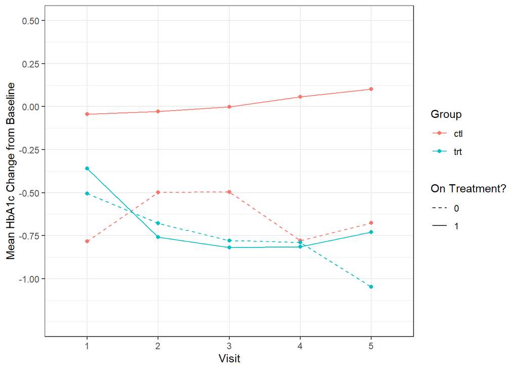

```r
# Create summary dataset of mean HbA1c change from baseline by visit, group and intercurrent event status
sumResponseByICE <- data_nomissing %>%
                    group_by(group, visitn, ontrt) %>%
                    summarize(n = n(),
                    resMean = mean(hba1cChg), .groups = "keep")

# Create figure showing mean HbA1c change from baseline by visit, group and intercurrent event status
ggplot(data = sumResponseByICE, aes(x = visitn, y = resMean,
                                      linetype = ontrt,
                                      color = group,
                                      group = interaction(group, ontrt))) +
  geom_point() +
  geom_line() +
  scale_linetype_manual(values=c("dashed", "solid")) +
  scale_y_continuous(breaks = seq(-1, 0.5, by = 0.25), limits = c(-1.25, 0.5)) +
  labs(x = "Visit", y = "Mean HbA1c Change from Baseline",
       color = "Group",
       linetype = "On Treatment?") +
  theme_bw() +
  theme(legend.position = "right")
```

## 2.3 Analysis of Data

As we have no missing data, we can perform our analysis just using ANCOVA. Our primary estimand is interested in the change in HbA1c from baseline to week 26 (visit 5), so we can restrict our analysis to `visitn==5`.

```r
#Perform ANCOVA
results_nomissing <- data_nomissing %>%
                      filter(visitn==5) %>%
                      lm(hba1cChg ~ group + hba1cBl,data=.)
summary(results_nomissing)
```

```
##
## Call:
## lm(formula = hba1cChg ~ group + hba1cBl, data = .)
##
## Residuals:
##     Min      1Q  Median      3Q     Max
## -3.1306 -0.7002 -0.0591  0.7915  3.2440
##
## Coefficients:
##             Estimate Std. Error t value Pr(>|t|)
## (Intercept)  5.94031    0.63404   9.369  < 2e-16 ***
## grouptrt    -0.68208    0.10915  -6.249 1.07e-09 ***
## hba1cBl     -0.76454    0.07976  -9.585  < 2e-16 ***
## ---
## Signif. codes:  0 '***' 0.001 '**' 0.01 '*' 0.05 '.' 0.1 ' ' 1
##
## Residual standard error: 1.092 on 397 degrees of freedom
## Multiple R-squared:  0.2482, Adjusted R-squared:  0.2444
## F-statistic: 65.52 on 2 and 397 DF,  p-value: < 2.2e-16
```

**Question 3:** What is the estimated treatment effect (the difference in change from baseline in HbA1c for treatment versus control group)? (Give answer with 2 decimal places)

**Question 4:** What is its standard error? (Give answer with 2 decimal places)

# 3 Trial with Missing Data

Now we will move onto the more realistic example, where unfortunately some patients did discontinue from the study at or after the time of treatment discontinuation. We will therefore have to use the estimation methods introduced in the lecture to impute the missing data for these patients under various assumptions.

## 3.1 Load Data

Load the dataset `DiabetesExampleData_missing.rds`, which contains the trial data where some patients have discontinued from the study at or after the time of treatment discontinuation.

```r
# Load the data
data_missing <- read_rds(here("DiabetesExampleData_missing.rds"))
```

## 3.2 Review Data

Let us take a look at this dataset. In particular, the level of missing data by treatment group.

```r
# Create flag to show if patient is on-treatment&study, off-treatment on-study, or off-treatment&study
data_missing <- data_missing %>%
  mutate(dispo = case_when(ontrt==1 ~ "On-treatment",
                           ontrt==0 & !is.na(hba1c) ~ "Off-treatment, on-study",
                           ontrt==0 & is.na(hba1c) ~ "Off-study"))

# Create summary table showing number and percentage of patients with missing data by visit and treatment group
data_missing %>%
  tabyl(dispo, visitn, group) %>%
  adorn_totals("row") %>%
  adorn_percentages("col") %>%
  adorn_pct_formatting(digits = 1) %>%
  adorn_ns(position = "front")
```

```
## $ctl
##                    dispo            1            2            3            4
##                Off-study   2   (1.0%)   7   (3.5%)  14   (7.0%)  24  (12.0%)
##  Off-treatment, on-study   6   (3.0%)  11   (5.5%)  17   (8.5%)  19   (9.5%)
##             On-treatment 192  (96.0%) 182  (91.0%) 169  (84.5%) 157  (78.5%)
##                    Total 200 (100.0%) 200 (100.0%) 200 (100.0%) 200 (100.0%)
##             5
##   32  (16.0%)
##   18   (9.0%)
##  150  (75.0%)
##  200 (100.0%)
##
## $trt
##                    dispo            1            2            3            4
##                Off-study   1   (0.5%)   4   (2.0%)   9   (4.5%)  14   (7.0%)
##  Off-treatment, on-study   4   (2.0%)   8   (4.0%)  11   (5.5%)  13   (6.5%)
##             On-treatment 195  (97.5%) 188  (94.0%) 180  (90.0%) 173  (86.5%)
##                    Total 200 (100.0%) 200 (100.0%) 200 (100.0%) 200 (100.0%)
##             5
##   16   (8.0%)
##   13   (6.5%)
##  171  (85.5%)
##  200 (100.0%)
```

**Question 5:** What percentage of trial participants in the active treatment group have some missing data? (Give answer with 1 decimal place)  
%

**Question 6:** What percentage of the trial participants in the control group have some missing data? (Give answer with 1 decimal place)  
%

## 3.3 Analysis of Data

### 3.3.1 Complete-Case Analysis

We know that a complete-case analysis is not the correct approach to take, but we will perform this naïve analysis in order to compare this with the results of the multiple imputation analysis.

```r
#Perform ANCOVA
results_completecase <- data_missing %>%
                      filter(visitn==5) %>%
                      lm(hba1cChg ~ group + hba1cBl,data=.)
summary(results_completecase)
```

```
##
## Call:
## lm(formula = hba1cChg ~ group + hba1cBl, data = .)
##
## Residuals:
##     Min      1Q  Median      3Q     Max
## -3.1634 -0.6974 -0.0336  0.7934  3.1896
##
## Coefficients:
##             Estimate Std. Error t value Pr(>|t|)
## (Intercept)  5.86939    0.67544   8.690  < 2e-16 ***
## grouptrt    -0.74453    0.11422  -6.518 2.49e-10 ***
## hba1cBl     -0.74898    0.08605  -8.704  < 2e-16 ***
## ---
## Signif. codes:  0 '***' 0.001 '**' 0.01 '*' 0.05 '.' 0.1 ' ' 1
##
## Residual standard error: 1.07 on 349 degrees of freedom
##   (48 observations deleted due to missingness)
## Multiple R-squared:  0.2602, Adjusted R-squared:  0.256
## F-statistic: 61.38 on 2 and 349 DF,  p-value: < 2.2e-16
```

**Question 7:** What is the estimated treatment effect (the difference in change from baseline in HbA1c for treatment versus control group)? (Give answer with 2 decimal places)

**Question 8:** What is its standard error? (Give answer with 2 decimal places)

### 3.3.2 Multiple imputation analysis

In order to perform the analysis targeting a treatment policy estimand we will use multiple imputation. Following the outline shown in the lecture, this approach will consist of four steps:

1. Fit the imputation model to the observed data.
2. Impute the missing data using the imputation model multiple times.
3. Analyse each complete data set.
4. Combine the results to obtain point estimate and variance estimation.

However, first we need to create:

- A dataset showing the visit when the intercurrent event occurred for each patient.
- A list of the key variables to be used in the imputation step.

```r
# Create tibble with time of treatment discontinuation and
#   the missing data imputation strategy for each subject
# Here we specify jump-to-reference (JR) strategy for all subjects
dat_ice <- data_missing %>%
            arrange(subjid, visitn) %>%
            filter(ontrt==0) %>%
            group_by(subjid) %>%
            slice(1) %>%
            ungroup() %>%
            mutate(strategy = case_when(
                    group == "ctl" ~ "JR",
                    group == "trt" ~ "JR" )) %>%
            select(subjid, visitn, strategy)

# Define the names of key variables in the dataset
# The specification here will be used in the imputation model
vars <- set_vars(outcome = "hba1cChg",
                 visit = "visitn",
                 subjid = "subjid",
                 group = "group",
                 covariates = c("hba1cBl*visitn", "group*visitn"),
                 strategy = "strategy")
```

### Step 1: Fit the imputation model to the observed data

```r
# Define which imputation method
# Here we use Bayesian multiple imputation with 250 imputed datasets
method <- method_bayes(burn_in = 200,
                        burn_between = 6,
                        n_samples = 250,
                        seed = 123456)

# Create samples for the imputation parameters by running the draws() function
set.seed(123456)
drawObj <- draws(data = data_missing,
                 data_ice = dat_ice,
                 vars = vars,
                 method = method)
```

### Step 2: Impute the missing data using the imputation model multiple times

```r
# Impute the data using the imputation model above
# In the dataset `dat_ice` we specified a jump-to-reference strategy
# Now we need to specify for each group what this 'reference' is
# Set reference arm in control group to itself to the control group
# Set reference arm in treatment group to control group
imputeObj <- impute(draws = drawObj,
                    references = c("trt"="ctl",
                                   "ctl"="ctl"))
```

### Step 3: Analyse each complete dataset

```r
# Fit the analysis model (ANCOVA) on each imputed dataset
# Analysis model includes group and baseline HbA1c as covariates
anaObj <- analyse(imputations = imputeObj,
                  fun = ancova,
                  vars = set_vars(outcome = "hba1cChg",
                                  visit = "visitn",
                                  subjid = "subjid",
                                  group = "group",
                                  covariates = "hba1cBl"))
```

### Step 4: Combine the results to obtain point estimate and variance estimation

```r
# Pool the results to get treatment effects
# In the output:
# trt_x refers to the difference between control and treatment group at visit x
# lsm_ref_x is the change from baseline in the reference group (control) at visit x
# lsm_alt_x is the change from baseline in the alternative group (treatment) at visit x
poolObj <- pool(results = anaObj, conf.level = 0.95, alternative = "two.sided")
poolObj
```

```
##
## Pool Object
## -----------
## Number of Results Combined: 250
## Method: rubin
## Confidence Level: 0.95
## Alternative: two.sided
##
## Results:
##
##   ==================================================
##    parameter   est     se     lci     uci     pval
##   --------------------------------------------------
##      trt_1    -0.287  0.053  -0.392  -0.183  <0.001
##    lsm_ref_1  -0.073  0.038  -0.147  0.001   0.054
##    lsm_alt_1  -0.36   0.038  -0.434  -0.286  <0.001
##      trt_2    -0.691  0.074  -0.836  -0.547  <0.001
##    lsm_ref_2  -0.052  0.052  -0.155   0.05   0.317
##    lsm_alt_2  -0.744  0.052  -0.846  -0.642  <0.001
##      trt_3    -0.704  0.091  -0.883  -0.525  <0.001
##    lsm_ref_3  -0.079  0.065  -0.207  0.048   0.223
##    lsm_alt_3  -0.783  0.064  -0.909  -0.657  <0.001
##      trt_4    -0.703  0.104  -0.908  -0.499  <0.001
##    lsm_ref_4  -0.055  0.075  -0.202  0.092    0.46
##    lsm_alt_4  -0.759  0.074  -0.903  -0.614  <0.001
##      trt_5    -0.717  0.116  -0.945  -0.489  <0.001
##    lsm_ref_5  0.011   0.084  -0.154  0.177   0.893
##    lsm_alt_5  -0.706  0.081  -0.864  -0.547  <0.001
##   --------------------------------------------------
```

*Note: Ensure to use set.seed(123456) to obtain same results*  
**Question 9:** What is the estimated treatment effect (the difference in change from baseline in HbA1c for treatment versus control group)? (Give answer with 2 decimal places)

**Question 10:** What is its standard error? (Give answer with 2 decimal places)

Compare these results to the results of the analysis of the dataset with no missing data, and the complete-case analysis.

# 4 Further work

## 4.1 Different reference assumptions

Look at the figure you created in **Section 2.2**. Do you think jump to reference was the correct imputation approach to take for the treatment arm? For the control arm? Was a suitable ‘reference’ group chosen?

Try running some different analyses on `data_missing` using different assumptions for the missing data. Strategies available in `rbmi` are:

- MAR - Missing At Random
- JR - Jump to Reference
- CR - Copy Reference
- CIR - Copy Increments in Reference
- LMCF - Last Mean Carried Forward

Note that in reality we never observe the missing data. Therefore, we would not be able to decide on the imputation strategy based on the data. Instead this should be based on clinically plausible assumptions depending on the therapeutic setting, disease characteristics and treatment mechanism.

```r
# Create tibble with time of treatment discontinuation and
#   the missing data imputation strategy for each subject
# Here we specify jump-to-reference (JR) strategy
dat_ice <- data_missing %>%
            arrange(subjid, visitn) %>%
            filter(ontrt==0) %>%
            group_by(subjid) %>%
            slice(1) %>%
            ungroup() %>%
            mutate(strategy = case_when(
                    group == "ctl" ~ "JR",
                    group == "trt" ~ "JR" )) %>%
            select(subjid, visitn, strategy)

# Define the names of key variables in the dataset
# The specification here will be used in the imputation model
vars <- set_vars(outcome = "hba1cChg",
                 visit = "visitn",
                 subjid = "subjid",
                 group = "group",
                 covariates = c("hba1cBl*visitn", "group*visitn"),
                 strategy = "strategy")

# Define which imputation method
# Here we use Bayesian multiple imputation with 250 imputed datasets
method <- method_bayes(burn_in = 200,
                        burn_between = 6,
                        n_samples = 250,
                        seed = 123456)

# Create samples for the imputation parameters by running the draws() function
set.seed(123456)
drawObj <- draws(data = data_missing,
                 data_ice = dat_ice,
                 vars = vars,
                 method = method)
# Impute the data using the imputation model above
# In the dataset `dat_ice` we specified a jump-to-reference strategy for the control group patients
# Now we need to specify for each group what this 'reference' is
# Set reference arm in control group to treatment group
# Set reference arm in treatment group to treatment group
imputeObj <- impute(draws = drawObj,
                    references = c("ctl"="trt",
                                   "trt"="trt"))

# Fit the analysis model (ANCOVA) on each imputed dataset
# Analysis model includes group and baseline HbA1c as covariates
anaObj <- analyse(imputations = imputeObj,
                  fun = ancova,
                  vars = set_vars(outcome = "hba1cChg",
                                  visit = "visitn",
                                  subjid = "subjid",
                                  group = "group",
                                  covariates = "hba1cBl"))

# Pool the results to get treatment effects
# In the output:
# trt_x refers to the difference between control and treatment group at visit x
# lsm_ref_x is the change from baseline in the reference group (control) at visit x
# lsm_alt_x is the change from baseline in the alternative group (treatment) at visit x
poolObj <- pool(results = anaObj, conf.level = 0.95, alternative = "two.sided")
poolObj
```

```
##
## Pool Object
## -----------
## Number of Results Combined: 250
## Method: rubin
## Confidence Level: 0.95
## Alternative: two.sided
##
## Results:
##
##   ==================================================
##    parameter   est     se     lci     uci     pval
##   --------------------------------------------------
##      trt_1    -0.286  0.053  -0.39   -0.181  <0.001
##    lsm_ref_1  -0.076  0.038  -0.15   -0.002  0.045
##    lsm_alt_1  -0.362  0.038  -0.436  -0.288  <0.001
##      trt_2    -0.68   0.073  -0.824  -0.536  <0.001
##    lsm_ref_2  -0.077  0.052  -0.179  0.025   0.137
##    lsm_alt_2  -0.757  0.052  -0.859  -0.656  <0.001
##      trt_3    -0.686  0.09   -0.863  -0.508  <0.001
##    lsm_ref_3  -0.125  0.064  -0.252  0.002   0.053
##    lsm_alt_3  -0.811  0.064  -0.936  -0.686  <0.001
##      trt_4    -0.665  0.102  -0.866  -0.464  <0.001
##    lsm_ref_4  -0.137  0.073  -0.281  0.007   0.061
##    lsm_alt_4  -0.803  0.072  -0.945  -0.66   <0.001
##      trt_5    -0.662  0.114  -0.885  -0.438  <0.001
##    lsm_ref_5  -0.092  0.083  -0.255   0.07   0.265
##    lsm_alt_5  -0.754  0.08   -0.911  -0.597  <0.001
##   --------------------------------------------------
```

## 4.2 Retrieved-dropout models

This practical above has only covered reference-based imputation methods. An alternative approach is to use retrieved-dropout models. The link below contains a vignette showing how the `rmbi` package can also be used to implement this approach.

https://insightsengineering.github.io/rbmi/main/articles/retrieved_dropout.html